[figure not shown]

6MT(TY85)-2

General Description

MANUAL TRANSMISSION AND DIFFERENTIAL

1. General Description

A: SPECIFICATION

1. MANUAL TRANSMISSION AND FRONT DIFFERENTIAL

2. TRANSMISSION GEAR OIL

Recommended oil:

GL-5 (75W-90) or equivalent

Type 6-forward speeds and 1-reverse (all stage with synchromesh)

TRANSMISSION GEAR RATIO

1st 3.636

2nd 2.235

3rd 1.521

4th 1.137

5th 0.971

6th 0.756

Rev. 3.545

Front reduction

gear

Final

Type of gear Hypoid

Gear ratio 3.900

Rear reduction

gear

Tra nsfer

Type of gear Helical

Gear ratio 1.103

Final

Type of gear Hypoid

Gear ratio 3.545

Front differential

Type and number of gear Planetary gear (pinion gear: 8, gear: 2)

LSD type Helical

Center differential Type and number of gear

Planetary gear

(Internal gear: 1, pinion gear: 6, sun gear: 1, and solenoid compression

variable control multiplate clutch)

Transmission gear oil capacity 4.1 L (4.3 US qt, 3.6 Imp qt)

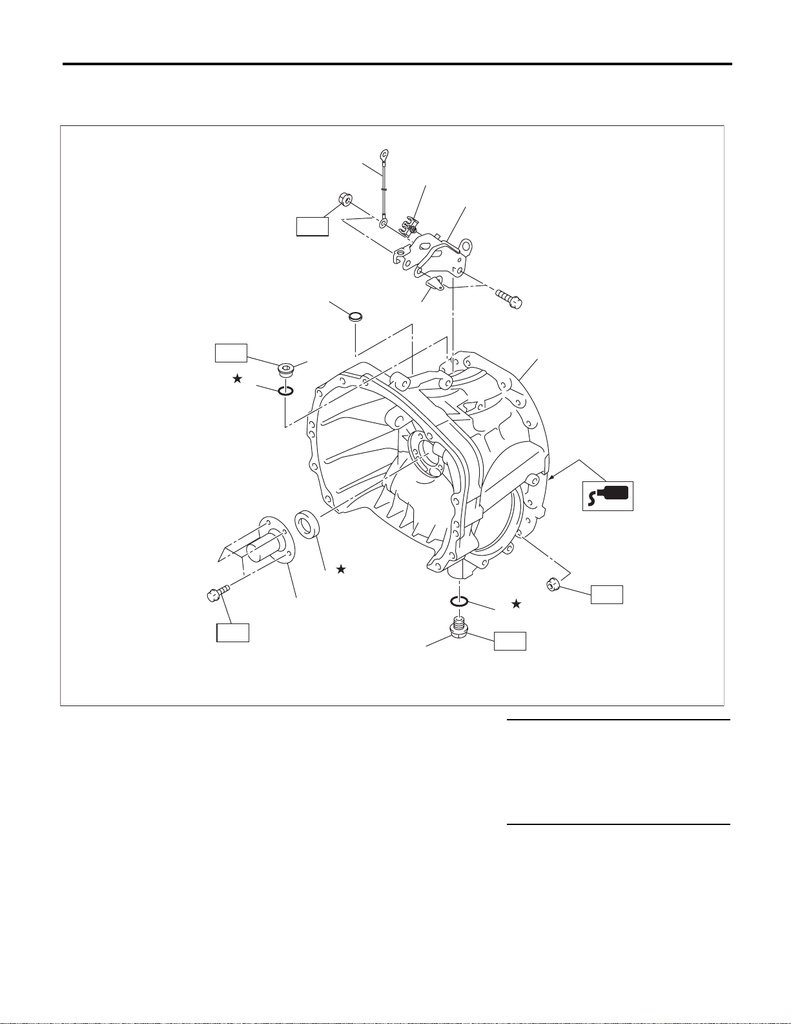

6MT(TY85)-3

General Description

MANUAL TRANSMISSION AND DIFFERENTIAL

B: COMPONENT

1. CLUTCH HOUSING

(1) Gasket (7) Oil seal Tightening torque: N·m (kgf-m, ft-lb)

(2) Plug (8) Clutch release bearing guide T1: 6.4 (0.7, 4.7)

(3) Pitching stopper bracket (9) Return spring bracket T2: 41 (4.2, 30.2)

(4) Clip (10) Plug T3: 50 (5.1, 36.9)

(5) Clutch housing (11) Drain plug T4: 70 (7.1, 51.6)

(6) Gasket (12) Transmission radio ground cord T5: 46 (4.7, 33.9)

MT-02307

(5)

(6)

(7)

(8)

T3

T4

T1

(4)

(3)

(2)

(9)

T2

(12)

(1)

(10)

(11)

T5

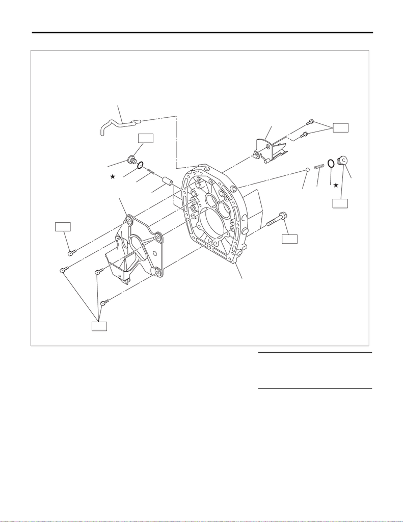

6MT(TY85)-4

General Description

MANUAL TRANSMISSION AND DIFFERENTIAL

2. ADAPTER PLATE

(1) Air breather hose (7) O-ring Tightening torque: N·m (kgf-m, ft-lb)

(2) Check plug (8) Checking spring T1: 18 (1.8, 13.3)

(3) O-ring (9) Check ball T2: 25 (2.5, 18.4)

(4) Checking spring (10) Oil guide A T3: 50 (5.1, 36.9)

(5) Plunger (11) Oil guide B

(6) Check plug (12) Adapter plate

MT-02308

(2)

(3)

(1)

(4)

(6)

(5)

(7)

(8)

(9)

(12)

T2

T1

T3

T2

T1

(11)

T1

(10)

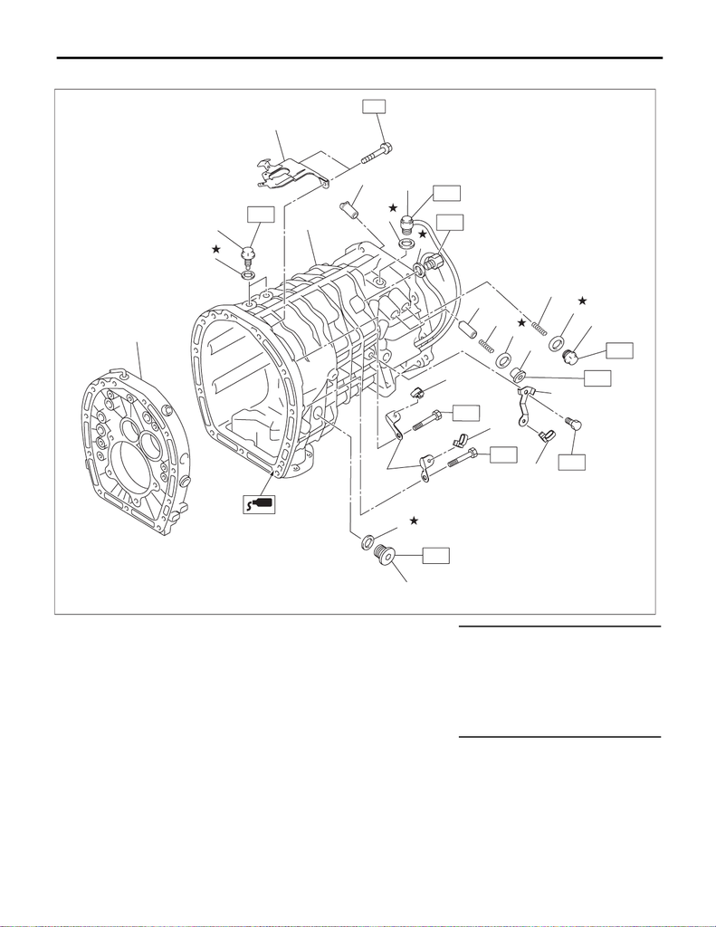

6MT(TY85)-5

General Description

MANUAL TRANSMISSION AND DIFFERENTIAL

3. TRANSMISSION CASE

(1) Adapter plate (10) Spring Tightening torque: N·m (kgf-m, ft-lb)

(2) Pilot bolt (11) Plug T1: 16 (1.6, 11.8)

(3) Gasket (12) O-ring T2: 25 (2.5, 18.4)

(4) Transmission harness stay (13) Spring T3: 32 (3.3, 23.6)

(5) Transmission case (14) Shift accent plunger T4: 34 (3.5, 25.1)

(6) Selector plunger (15) Harness bracket T5: 41 (4.2, 30.2)

(7) Neutral switch (16) Band clip T6: 50 (5.1, 36.9)

(8) Back-up light switch (17) Filler plug

(9) Plug

(7)

(8)

(2)

(3)

(3)

(3)

(1)

(5)

T3

T4

T3

T1

(15)

(9)

(3)

(10)

(6)

T5

T6

(17)

(3)

T6

T6

MT-03064

(16)

(16)

(15)

(16)

(4)

T6

(12)

(13)

(11)

(14)

T2

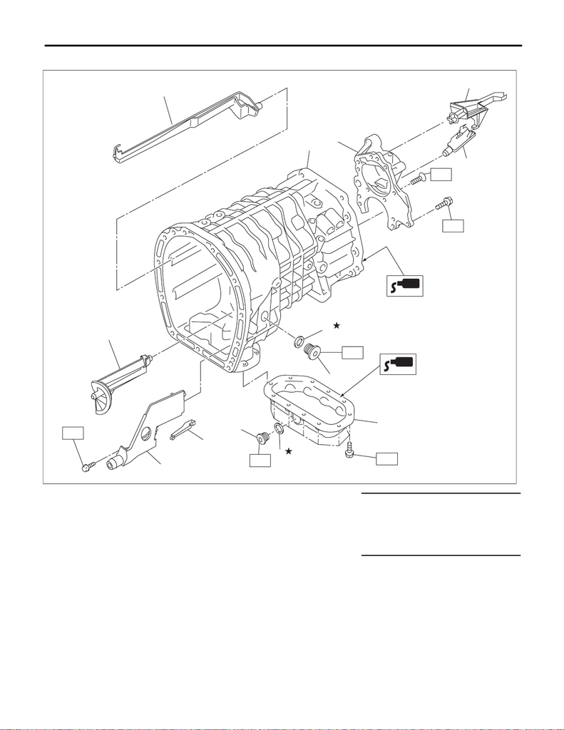

6MT(TY85)-6

General Description

MANUAL TRANSMISSION AND DIFFERENTIAL

4. OIL PAN & OIL GUIDE

(1) Transmission case (7) Oil guide F Tightening torque: N·m (kgf-m, ft-lb)

(2) Transfer bearing holder (8) Oil guide D T1: 6.4 (0.7, 4.7)

(3) Oil guide G (9) Oil guide E T2: 18 (1.8, 13.3)

(4) Oil guide H (10) Oil guide C T3: 25 (2.5, 18.4)

(5) Oil pan (11) Filler plug T4: 50 (5.1, 36.9)

(6) Gasket (12) Drain plug

MT-03065

(2)

(3)

(4)

T3

T3

(1)

T2

(10)

(7)

(8)

(9)

(5)

(6)

T1

T4

T4

(11)

(6)

(12)

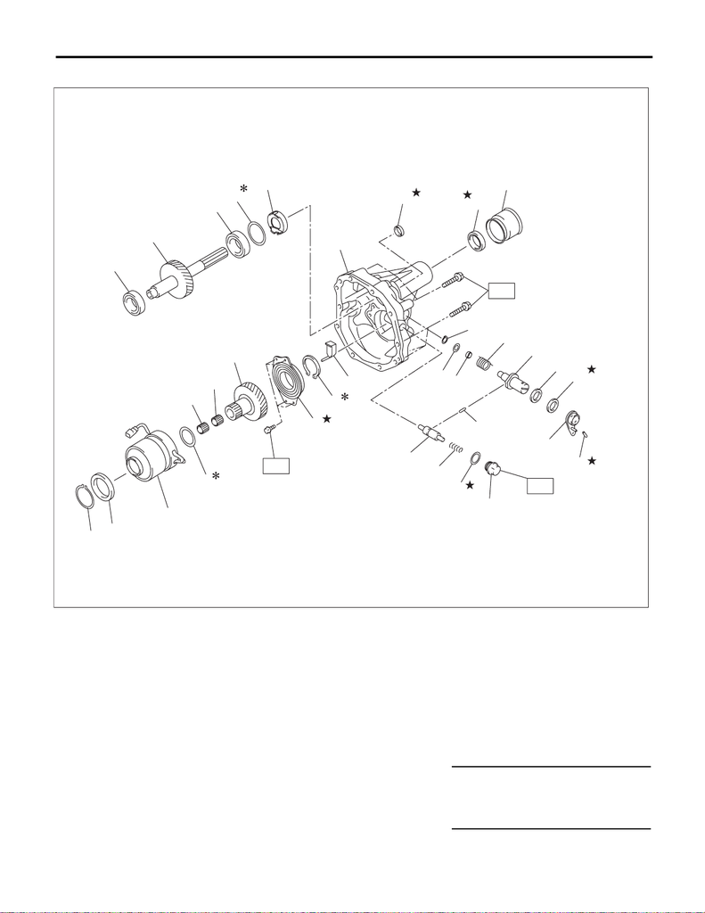

6MT(TY85)-7

General Description

MANUAL TRANSMISSION AND DIFFERENTIAL

5. EXTENSION CASE AND CENTER DIFFERENTIAL

(1) Taper roller bearing (transmission

case side)

(14) Snap ring (27) Reverse check lever

(2) Transfer driven gear (15) Oil guide (28) Straight pin

(3) Taper roller bearing (extension

case side)

(16) Extension case (29) Reverse check plunger

(4) Adjusting washer (17) Oil seal (30) Spring

(5) Oil plate (18) Oil seal (31) Gasket

(6) Snap ring (19) Dust cover (32) Plug

(7) Collar (20) Snap ring (33) Reverse lock plunger

(8) Center differential (21) Washer

(9) Adjusting washer (22) Bushing Tightening torque: N·m (kgf-m, ft-lb)

(10) Needle bearing (23) Spring T1: 25 (2.5, 18.4)

(11) Needle bearing (24) Reverse check shaft T2: 41 (4.2, 30.2)

(12) Transfer drive gear (25) Ball bearing T3: 48 (4.9, 35.4)

(13) Ball bearing (with flange) (26) Oil seal

(32)

(31)

(30)

(33)

(27)

(26)

(25)

(24)

(23)

(22)

(21)

(20)

(19)

(18)

(17)

(16)

(15)

(14)

(13)

(12)

(11)

(10)

(5)

(4)

(3)

(2)

(9)

(1)

(28)

(29)

T3

T1

T2

(8)

MT-02934

(6)

(7)

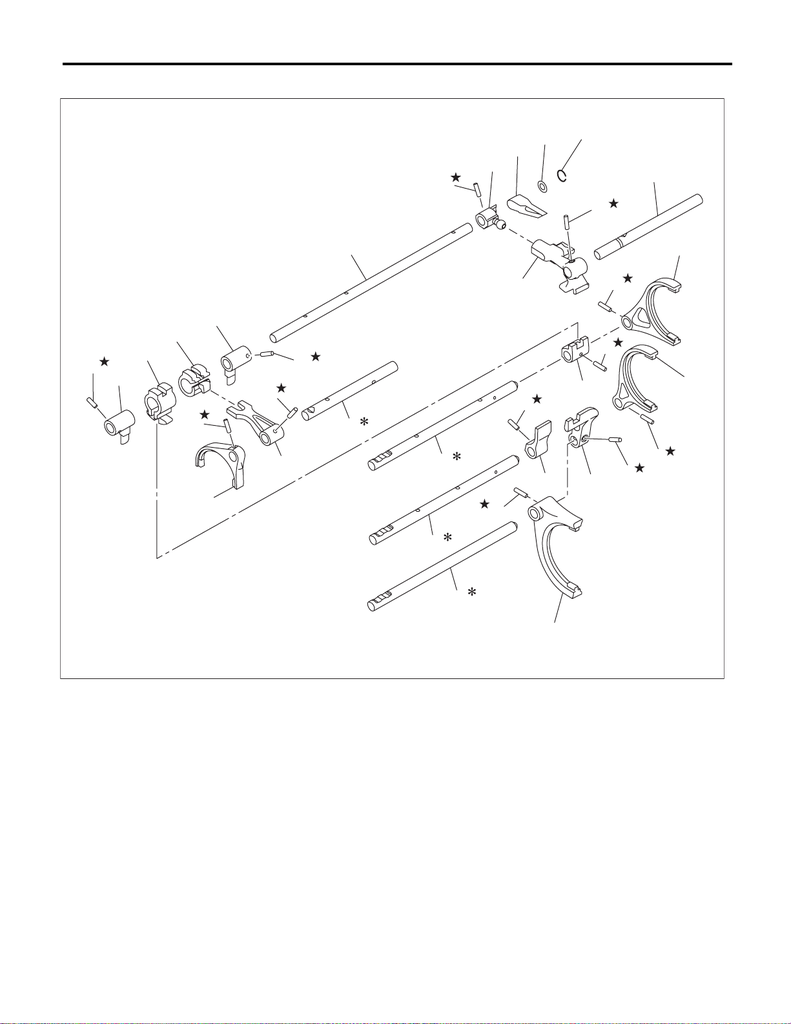

6MT(TY85)-8

General Description

MANUAL TRANSMISSION AND DIFFERENTIAL

6. SHIFTER FORK AND FORK ROD

(1) Straight pin (9) Washer (17) 5th-6th shifter arm

(2) Interlock arm (10) Snap ring (18) 5th-6th shifter fork

(3) Interlock block (11) Reverse shifter fork (19) 3rd-4th fork rod

(4) Reverse interlock block (12) Reverse shifter arm (20) 3rd-4th shifter arm

(5) Interlock arm (13) Reverse fork rod (21) 1st-2nd shifter arm

(6) Striking rod (14) Selector arm (22) 3rd-4th shifter fork

(7) Selector arm No. 2 (15) Shifter arm shaft (23) 1st-2nd fork rod

(8) Neutral set spring (16) 5th-6th fork rod (24) 1st-2nd shifter fork

(7)

(8)

(9)

(10)

(15)

(14)

(18)

(17)

(22)

(1)

(1)

(20)

(1)

(1)

(1)

(1)

(1)

(21)

(24)

(1)

(19)

(16)

(13)

(12)

(11)

(23)

(1)

(1)

(1)

(1)

(5)

(6)

(4)

(3)

(2)

MT-03142

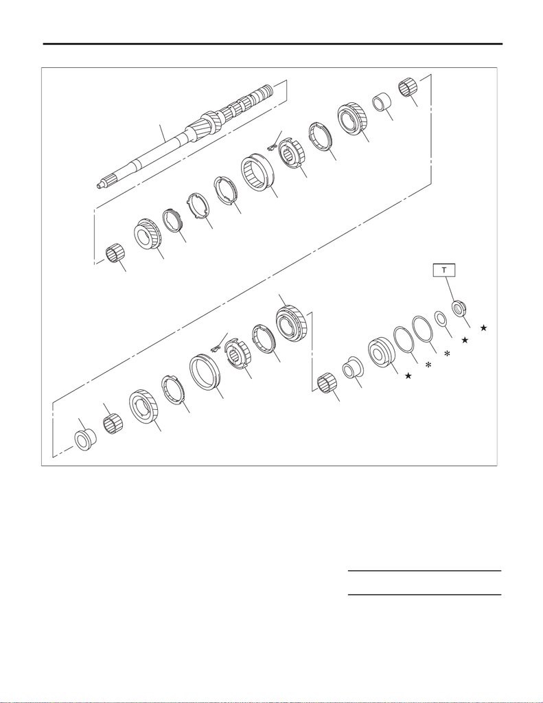

6MT(TY85)-9

General Description

MANUAL TRANSMISSION AND DIFFERENTIAL

7. MAIN SHAFT ASSY

(1) Main shaft (12) 4th needle bearing race (23) Needle bearing

(2) Needle bearing (13) Needle bearing (24) 6th drive gear bushing

(3) 3rd drive gear (14) 5th drive gear bushing (25) Double taper roller bearing

(4) 3rd inner baulk ring (15) Needle bearing (26) Snap ring

(5) 3rd synchro cone (16) 5th drive gear (27) Adjusting washer

(6) 3rd outer baulk ring (17) 5th baulk ring (28) Lock washer

(7) 3rd-4th coupling sleeve (18) 5th-6th coupling sleeve (29) Lock nut

(8) 3rd-4th synchronizer hub (19) 5th-6th synchronizer hub

(9) 3rd-4th shifting insert (20) 5th-6th shifting insert Tightening torque: N·m (kgf-m, ft-lb)

(10) 4th baulk ring (21) 6th baulk ring T: 392 (40.0, 289.1)

(11) 4th drive gear (22) 6th drive gear

MT-02935

(2)

(16)

(17)

(18)

(19)

(21)

(22)

(23)

(24)

(25)

(26)

(27)

(28)

(29)

(14)

(15)

(3)

(4)

(5)

(6)

(7)

(8)

(9)

(1)

(10)

(11)

(12)

(13)

(20)

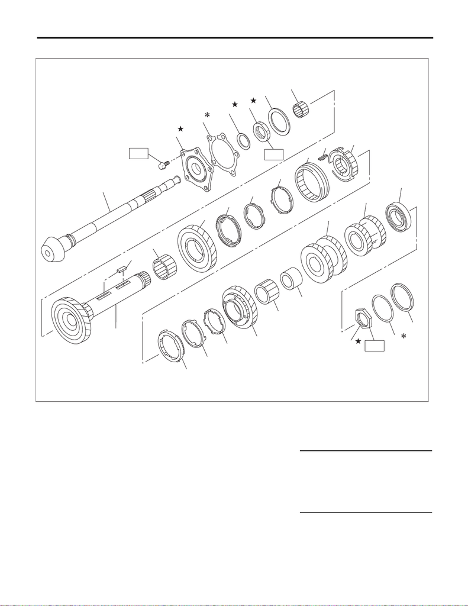

6MT(TY85)-10

General Description

MANUAL TRANSMISSION AND DIFFERENTIAL

8. DRIVE PINION SHAFT ASSY & DRIVEN GEAR ASSY

(1) Drive pinion shaft (14) 1st inner baulk ring (27) Lock nut

(2) Double taper roller bearing (15) 1st-2nd coupling sleeve (28) Adjusting washer

(3) Drive pinion shim (16) 1st-2nd shifting insert (29) Collar

(4) Lock washer (17) 1st-2nd synchronizer hub

(5) Lock nut (18) 2nd outer baulk ring Tightening torque: N·m (kgf-m, ft-lb)

(6) Thrust bearing (19) 2nd synchro cone T1: 285 (29.1, 210.2)

(7) Needle bearing (20) 2nd inner baulk ring *265 (27.0, 195.4)

(8) Driven shaft (21) 2nd driven gear T2: 570 (58.1, 420.4)

(9) Key (22) Needle bearing *530 (54.0, 390.9)

(10) Needle bearing (23) 2nd driven gear bushing T3: 54 (5.5, 39.8)

(11) 1st driven gear (24) 3rd-4th driven gear * Tightening torque when using the ST

(12) 1st outer baulk ring (25) 5th-6th driven gear

(13) 1st synchro cone (26) Ball bearing

MT-03198

(28)

(27)

(29)

(18)

(19)

(20)

(21)

(22)

(8)

(1)

(2)

(10)

(9)

(11)

(12)

(13)

(14)

(15)

(16)

(17)

(24)

(25)

(26)

(3)

(5)

(6)

(7)

T1

T2

(4)

(23)

T3

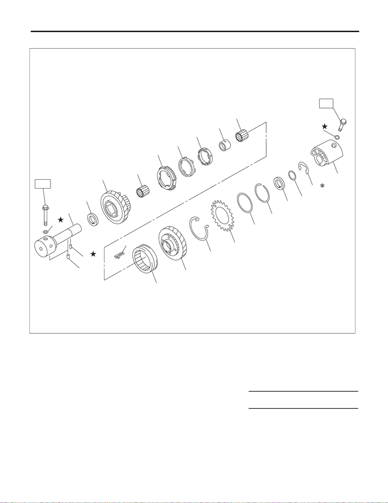

6MT(TY85)-11

General Description

MANUAL TRANSMISSION AND DIFFERENTIAL

9. REVERSE IDLER GEAR ASSY

(1) Reverse idler gear shaft (10) Reverse inner baulk ring (19) Snap ring

(2) Gasket (11) Reverse idler gear bushing (20) Counter high and low washer

(3) Knock pin (12) Needle bearing (21) Washer

(4) Straight pin (13) Shifting insert (22) Snap ring

(5) Counter high and low washer (14) Reverse coupling sleeve (23) Reverse idler holder

(6) Reverse idler gear No. 2 (15) Reverse idler gear

(7) Needle bearing (16) Spring Tightening torque: N·m (kgf-m, ft-lb)

(8) Reverse outer baulk ring (17) Reverse idler sub gear T: 25 (2.5, 18.4)

(9) Reverse synchro cone (18) Friction plate

(1)

(14)

(4)

(3)

(13)

(15)

(16)

(17)

(18)

(20)

(22)

(19)

(23)

(5)

(6)

(7)

(10)

(9)

(8)

(11)

(12)

T

T

(2)

(2)

(21)

MT-03199

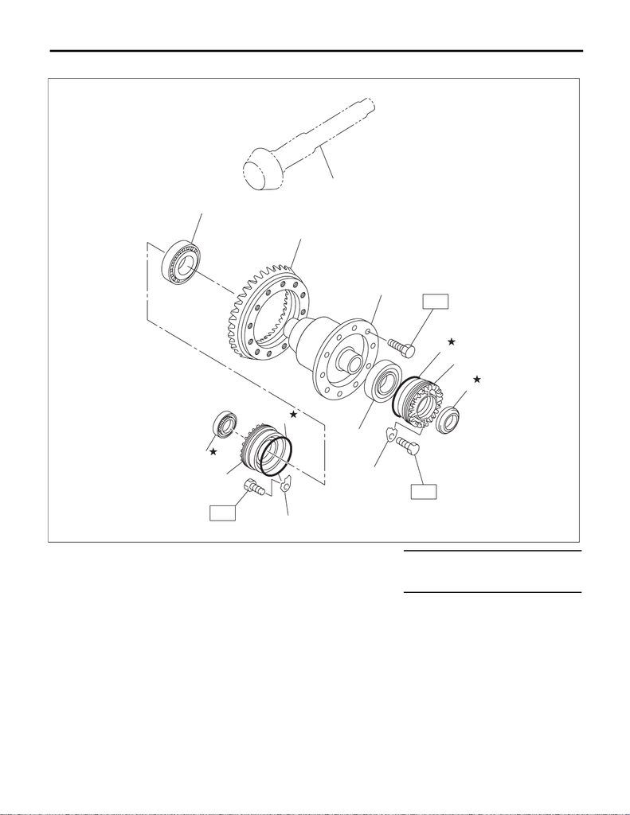

6MT(TY85)-12

General Description

MANUAL TRANSMISSION AND DIFFERENTIAL

10.FRONT DIFFERENTIAL ASSY

(1) Drive pinion shaft (5) Oil seal Tightening torque: N·m (kgf-m, ft-lb)

(2) Hypoid driven gear (6) Differential side retainer T1: 25 (2.5, 18.4)

(3) Taper roller bearing (7) O-ring T2: 69 (7.0, 50.9)

(4) Differential ASSY (8) Retainer lock plate

MT-01705

(1)

(2)

T1

T2

(4)

(3)

(5)

(7)

(6)

(8)

(3)

(7)

(8)

T1

(6)

(5)

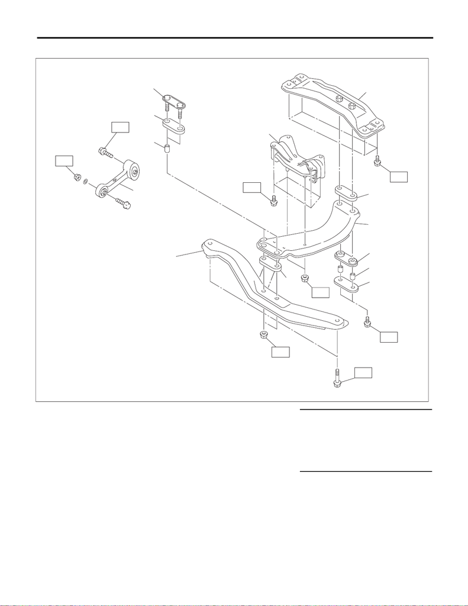

6MT(TY85)-13

General Description

MANUAL TRANSMISSION AND DIFFERENTIAL

11.TRANSMISSION MOUNTING

(1) Pitching stopper (7) Upper cushion rubber Tightening torque: N·m (kgf-m, ft-lb)

(2) Spacer (8) Center crossmember T1: 35 (3.6, 25.8)

(3) Lower cushion rubber (9) Rear plate T2: 50 (5.1, 36.9)

(4) Front plate (10) Front crossmember T3: 58 (5.9, 42.8)

(5) Transmission cushion rubber (11) Rear cushion rubber T4: 70 (7.1, 51.6)

(6) Rear crossmember T5: 140 (14.3, 103.3)

(1)

T3

T4

T4

T4

T1

T5

T1

T2

(2)

(4)

(5)

(11)

(8)

(7)

(3)

(2)

(9)

(6)

(3)

(10)

MT-03181

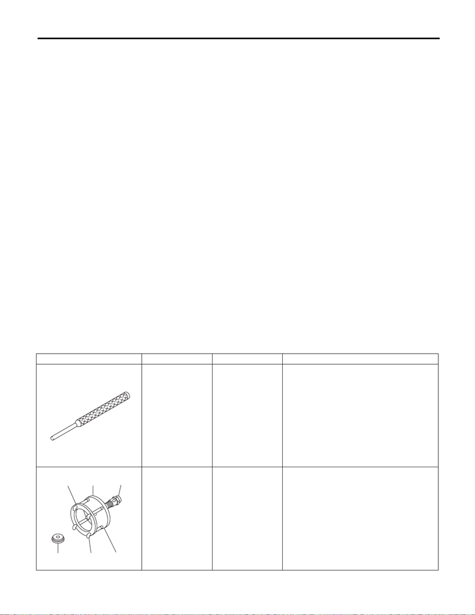

6MT(TY85)-14

General Description

MANUAL TRANSMISSION AND DIFFERENTIAL

C: CAUTION

• Remove contamination including dirt and corrosion before removal, installation or disassembly.

• Keep the disassembled parts in order and protect them from dust and dirt.

• Before removal, installation or disassembly, be sure to clarify the failure. Avoid unnecessary removal, in-

stallation, disassembly and replacement.

• When disassembling the case and other light alloy parts, disassemble by using a plastic hammer. Do not

pry apart with screwdrivers or other tools.

• Vehicle components are extremely hot after driving. Be wary of receiving burns from heated parts.

• Use SUBARU genuine transmission gear oil, grease or equivalent. Do not mix transmission gear oil,

grease etc. of different grades or manufacturers.

• Be sure to tighten fasteners including bolts and nuts to the specified torque.

• Place shop jacks or rigid racks at the specified points.

• Apply transmission gear oil onto sliding or revolving surfaces before installation.

• Always replace deformed or damaged snap rings.

• Before installing O-rings or oil seals, apply sufficient amount of transmission gear oil to avoid damage and

deformation.

• Be careful not to incorrectly install or fail to install O-rings, snap rings and other such parts.

• Before securing a part on a vise, place cushioning materials such as wood blocks, aluminum plates, or

waste cloth between the part and the vise.

• Avoid damaging the mating surface of the case.

• Before applying liquid gasket, completely remove and clean the old liquid gasket.

• Be careful of handling the oil seal, O-ring and gasket. If the contact surface of them is damaged, oil leakage

may occur.

• When pressing-in the oil seal, make sure that the oil seal lip portion and outer surface are not damaged or

tilted.

• When replacing the taper roller bearing, replace the outer race and inner race as a set.

• When replacing the hypoid gear, replace the ring gear and pinion gear as a set.

• Replace the bolts if the seating surface or the thread surface is excessively rusted.

D: PREPARATION TOOL

1. SPECIAL TOOL

ILLUSTRATION TOOL NUMBER DESCRIPTION REMARKS

398791700 REMOVER Used for removing and installing the straight pin

(6 mm).

399527700 PULLER SET Used for removing and installing the roller bear-

ing (differential).

(1) BOLT (899521412)

(2) PULLER (399527702)

(3) HOLDER (399527703)

(4) ADAPTER (398497701)

(5) BOLT (899520107)

(6) NUT (021008000)

ST-398791700

ST-399527700

(1)

(2)

(3)

(4)

(5)

(6)

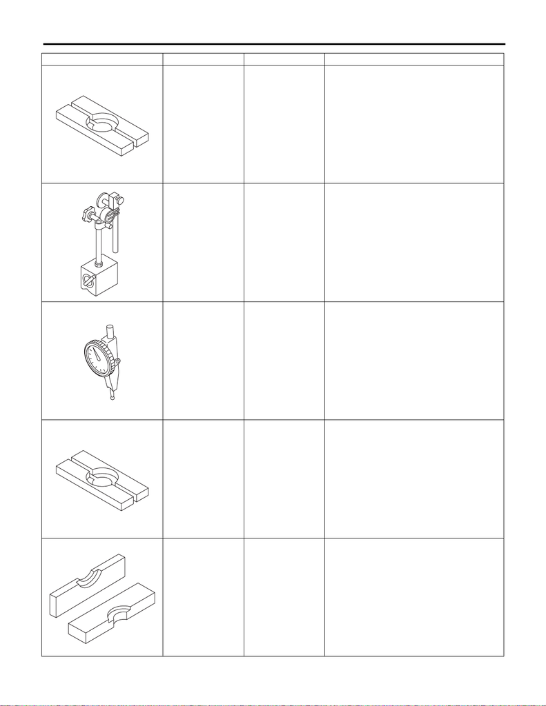

6MT(TY85)-15

General Description

MANUAL TRANSMISSION AND DIFFERENTIAL

498515700 REMOVER Used for removing the roller bearing of the trans-

fer driven gear.

498247001 MAGNET BASE • Used for measuring the backlash between

hypoid gears.

• Used with DIAL GAUGE (498247100).

498247100 DIAL GAUGE • Used for measuring the backlash between

hypoid gears.

• Used with MAGNET BASE (498247001).

498077000 REMOVER Used for removing the differential taper roller

bearing.

899858600 REMOVER Used for removing the roller bearing.

ILLUSTRATION TOOL NUMBER DESCRIPTION REMARKS

ST-498515700

ST-498247001

ST-498247100

ST-498077000

ST-899858600

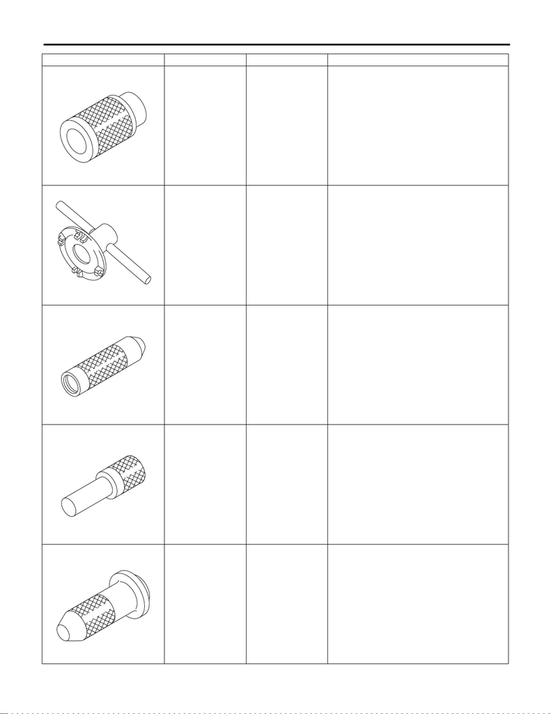

6MT(TY85)-16

General Description

MANUAL TRANSMISSION AND DIFFERENTIAL

499757002 INSTALLER Used for installing the bearing cone of transfer

driven gear (transmission case side).

18630AA010 WRENCH COMPL

RETAINER

• Used for removing and installing the differen-

tial side retainer RH.

• WRENCH ASSY (499787000) can also be

used.

499877000 RACE 4-5

INSTALLER

Used for disassembling the driven shaft and

transfer driven gear.

899864100 REMOVER Used for removing the transmission main shaft

and drive pinion parts.

498057300 INSTALLER Used for installing the extension oil seal.

ILLUSTRATION TOOL NUMBER DESCRIPTION REMARKS

ST-499757002

ST18630AA010

ST-499877000

ST-899864100

ST-498057300

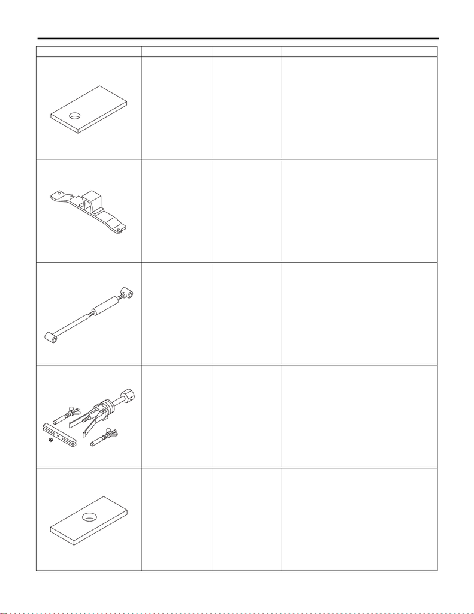

6MT(TY85)-17

General Description

MANUAL TRANSMISSION AND DIFFERENTIAL

498255400 PLATE Used for measuring backlash.

41099AA011 ENGINE SUPPORT

BRACKET

• Used for supporting engine.

• ENGINE SUPPORT BRACKET (41099AA010)

can also be used.

41099AA020 ENGINE SUPPORT Used for supporting engine.

398527700 PULLER ASSY • Used for removing the extension case oil seal.

• Used for removing the front differential side

bearing outer race. (Used together

with18760AA000 (CLAW).)

398643600 GAUGE Used for adjusting total end play, extension end

play and drive pinion shim.

ILLUSTRATION TOOL NUMBER DESCRIPTION REMARKS

ST-498255400

ST41099AA011

ST41099AA020

ST-398527700

ST-398643600

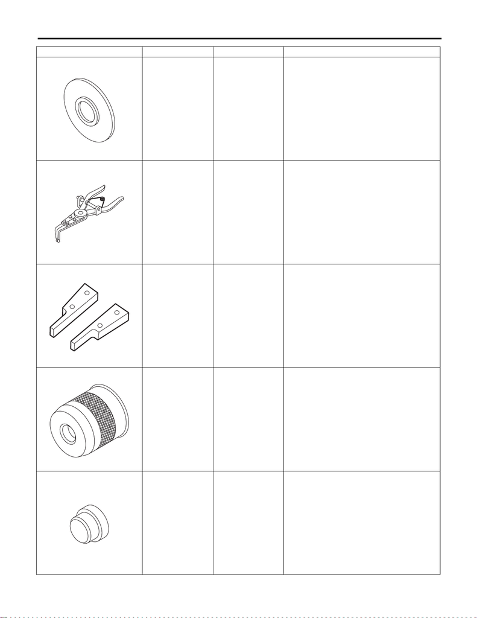

6MT(TY85)-18

General Description

MANUAL TRANSMISSION AND DIFFERENTIAL

398177700 INSTALLER • Used for assembling the main shaft.

• Used for installing the roller bearing of transfer

driven gear (extension case side).

399893600 PLIER • Used for removing and installing the neutral

set spring.

• Used together with CLAW (18756AA000).

18756AA000 CLAW • Used for removing and installing the neutral

set spring.

• Used together with PLIER (399893600).

499247400 INSTALLER Used for installing the ball bearing of the transfer

drive gear.

398497701 SEAT • Used for installing the ball bearing of the trans-

fer drive gear.

• Used for installing the front differential side

bearing.

ILLUSTRATION TOOL NUMBER DESCRIPTION REMARKS

ST-398177700

ST-399893600

ST18756AA000

ST-499247400

ST-398497701

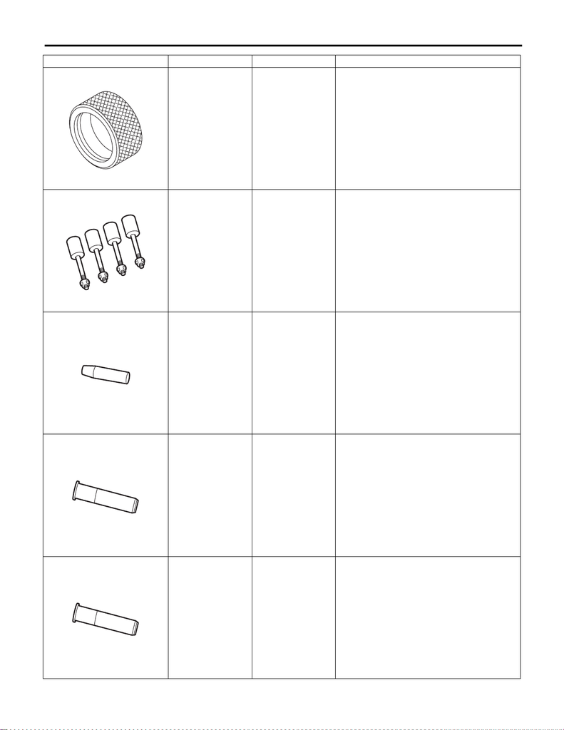

6MT(TY85)-19

General Description

MANUAL TRANSMISSION AND DIFFERENTIAL

398437700 INSTALLER Used for installing the front differential side bear-

ing.

18632AA000 STAND ASSY Used for disassembling and assembling the

transmission.

18671AA000 OIL SEAL GUIDE • Used for installing the reverse check shaft oil

seal.

• Used for installing the shifter arm oil seal.

• Used together with INSTALLER

(18657AA010).

18657AA010 INSTALLER • Used for installing the reverse check shaft oil

seal.

• Used together with OIL SEAL GUIDE

(18671AA000).

18657AA000 INSTALLER • Used for installing the shifter arm oil seal.

• Used together with OIL SEAL GUIDE

(18671AA000).

ILLUSTRATION TOOL NUMBER DESCRIPTION REMARKS

ST-398437700

ST18632AA000

ST18671AA000

ST18657AA010

ST18657AA000

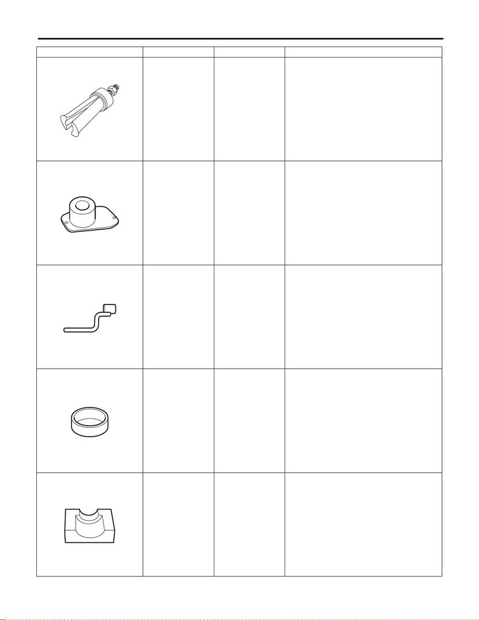

6MT(TY85)-20

General Description

MANUAL TRANSMISSION AND DIFFERENTIAL

18758AA000 PULLER Used for removing the transfer driven gear rear

bearing outer race.

18831AA000 GAUGE Used for selecting the transfer driven gear bear-

ing adjusting washer.

18631AA000 HANDLE Used for measuring the front differential back-

lash.

18754AA000 REMOVER Used to remove parts of the driven gear.

18665AA000 HOLDER • Used for removing and installing the main

shaft lock nut.

• Used together with BASE (18664AA000).

ILLUSTRATION TOOL NUMBER DESCRIPTION REMARKS

ST18758AA000

ST18831AA000

ST18631AA000

ST18754AA000

ST18665AA000

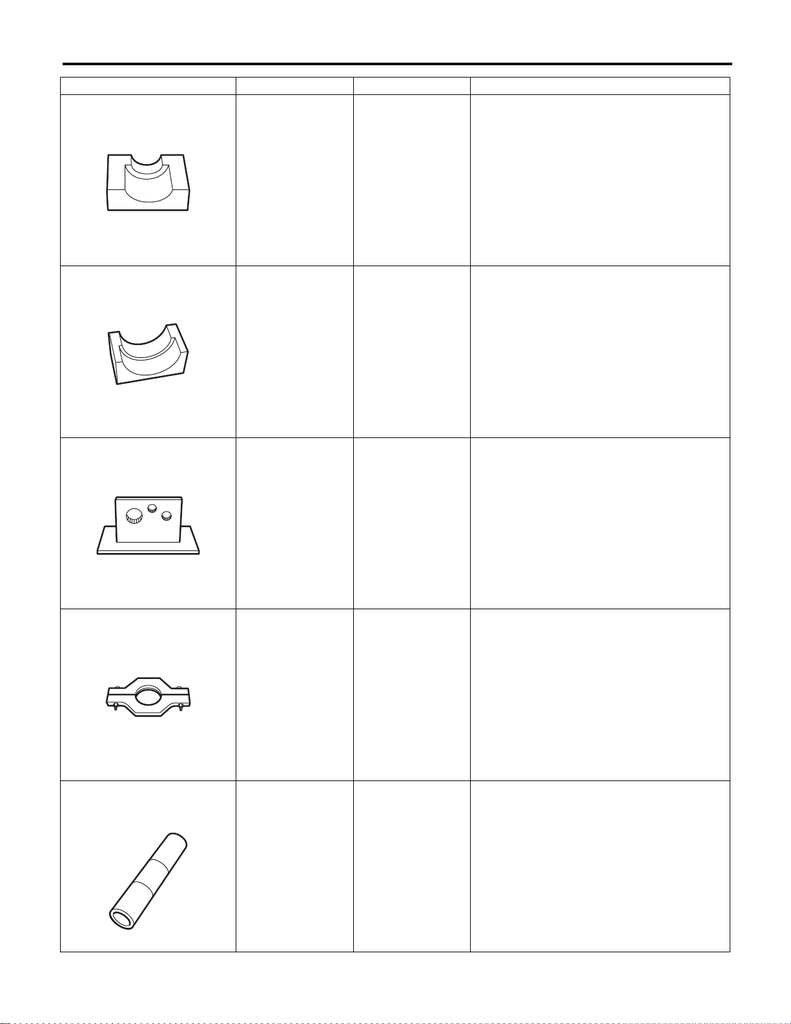

6MT(TY85)-21

General Description

MANUAL TRANSMISSION AND DIFFERENTIAL

18666AA000 HOLDER • Used for removing and installing the driven

shaft lock nut.

• Used together with BASE (18664AA000).

18667AA000 HOLDER • Used for removing and installing the drive pin-

ion shaft lock nut.

• Used together with BASE (18664AA000).

18664AA000 BASE • Used for removing and installing the main

shaft lock nut.

• Used for removing and installing the drive pin-

ion shaft lock nut.

• Used for removing and installing the driven

shaft lock nut.

18722AA010 REMOVER Used for disassembling the main shaft.

18651AA000 INSTALLER Used for assembling the main shaft.

ILLUSTRATION TOOL NUMBER DESCRIPTION REMARKS

ST18666AA000

ST18667AA000

ST18664AA000

ST18722AA010

ST18651AA000

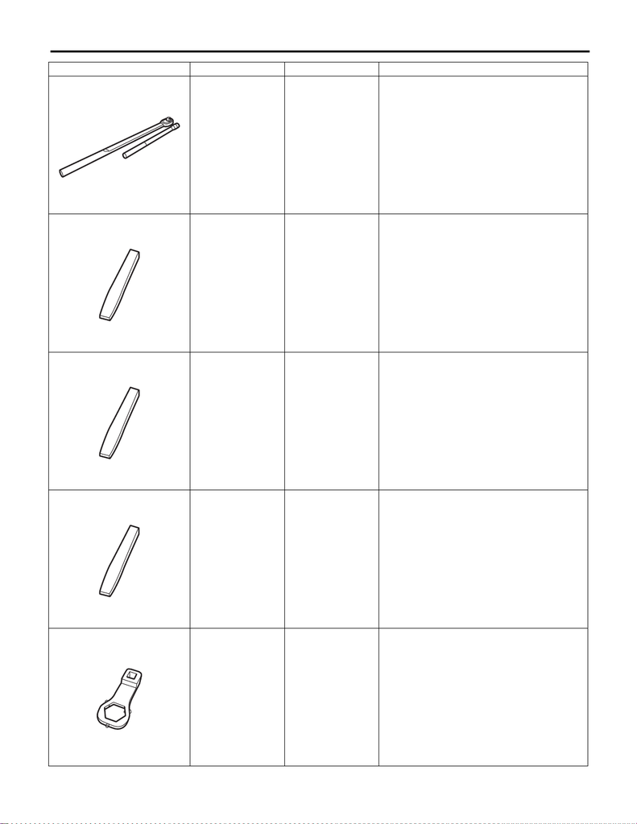

6MT(TY85)-22

General Description

MANUAL TRANSMISSION AND DIFFERENTIAL

18852AA000 TORQUE WRENCH • Used to tighten the main shaft lock nut.

• Used to tighten the drive pinion shaft lock nut.

• Used to tighten the driven shaft lock nut.

18668AA000 PUNCH Used to crimp the main shaft lock nut.

18669AA000 PUNCH Used to crimp the driven shaft lock nut.

18670AA000 PUNCH Used to crimp the drive pinion shaft lock nut.

18620AA000 ADAPTER

WRENCH

Used for removing and installing the driven gear

shaft lock nut.

ILLUSTRATION TOOL NUMBER DESCRIPTION REMARKS

ST18852AA000

ST18668AA000

ST18669AA000

ST18670AA000

ST18620AA000

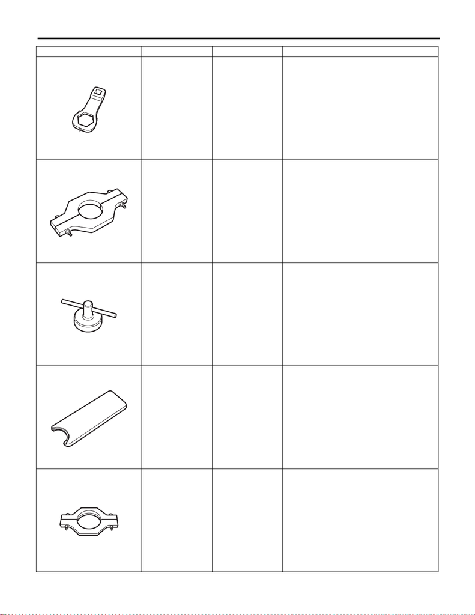

6MT(TY85)-23

General Description

MANUAL TRANSMISSION AND DIFFERENTIAL

18621AA000 ADAPTER

WRENCH

Used for removing and installing the drive pinion

shaft lock nut.

18723AA000 REMOVER Used for disassembling the driven shaft.

18630AA000 WRENCH ASSY Used for removing and installing the differential

side retainer LH.

18672AA000 GUIDE CLIP Used for installing the reverse idler snap ring.

18720AA000 REMOVER Used for disassembling the main shaft.

ILLUSTRATION TOOL NUMBER DESCRIPTION REMARKS

ST18621AA000

ST18723AA000

ST18630AA000

ST18672AA000

ST18720AA000

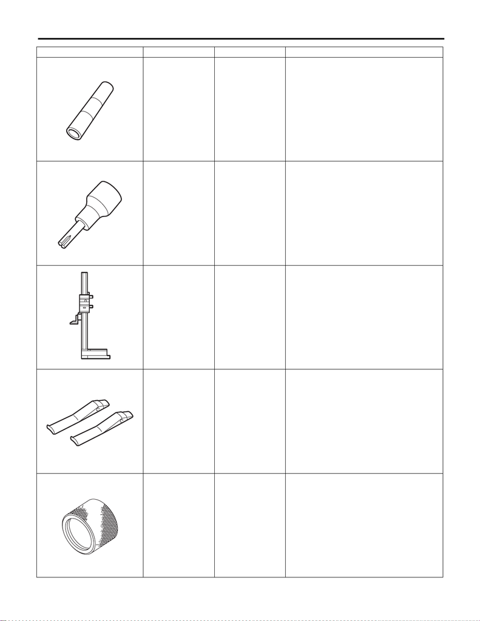

6MT(TY85)-24

General Description

MANUAL TRANSMISSION AND DIFFERENTIAL

18654AA000 INSTALLER Used for assembling the driven shaft.

18663AA000 SOCKET Used for removing and installing the transfer

bearing holder.

18853AA000 HEIGHT GAUGE • Used for selecting the shift rod.

• Used for selecting the snap ring and washer of

the main shaft.

18760AA000 CLAW • Used for removing the front differential side

bearing outer race.

• Used together with PULLER ASSY

(398527700).

18675AA000 DIFFERENTIAL

SIDE OIL SEAL

INSTALLER

Used for installing the differential side retainer oil

seal.

ILLUSTRATION TOOL NUMBER DESCRIPTION REMARKS

ST18654AA000

ST18663AA000

ST18853AA000

ST18760AA000

ST18675AA000

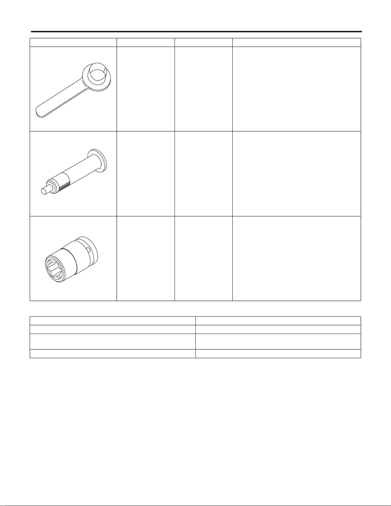

6MT(TY85)-25

General Description

MANUAL TRANSMISSION AND DIFFERENTIAL

2. GENERAL TOOL

28399SA010 OIL SEAL PROTEC-

TOR

Used for protecting oil seal when installing front

drive shaft.

18657AA020 OIL SEAL

INSTALLER

Used for installing the oil seal.

18270KA020 SOCKET (E20) Used for removing and installing the hypoid

driven gear.

TOOL NAME REMARKS

Circuit tester Used for measuring resistance, voltage and current.

TORX

®

bit T70 Used for removing and installing transmission gear oil drain

plug.

Depth gauge Used for measuring the transmission end play.

ILLUSTRATION TOOL NUMBER DESCRIPTION REMARKS

ST28399SA010

ST18657AA020

ST18270KA020